# Analyze Quality Wine with Naive Bayes, Decision Tree, and Random Forest

Gasha Sarwono

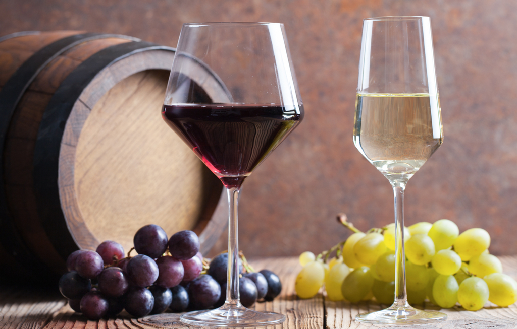

## Background

**This is data characteristic about wine quality, like chemical content and quality standard.**

**My purpose use this data is to analysis quality of wine based on chemical content.**

**Description Data:**

- fixed acidity: most acids involved with wine
- volatile acidity: amount of acetic acid in wine
- citric acid: found in small quantities
- residual sugar: amount of sugar remaining after wine fermentation/production
- chlorides: amount of salt in the wine
- free sulfur dioxide: free forms of S02, prevents microbial growth and the oxidation of wine
- total sulfur dioxide: amount of free and bound forms of S02
- density: the density of water depending on the percent alcohol and sugar content
- pH: describes how acidic or basic a wine is on a scale 0-14 (very acidic: 0, very basic: 14); most wines are between 3-4 on the pH scale
- sulphates: an antimicrobial and antioxidant
- alcohol: the percent alcohol content of the wine

## Set Up

**Activated Library**

```r
library(dplyr) #wrangling data
library(tidyverse) #make plot
library(caret) #confussion matrix
library(rsample) #sampling data
library(e1071) #naive bayes
library(partykit) #decisioin tree
library(randomForest) #random forest
library(ROCR) #check ROC

options(scipen = 999)
```

**Import Data**

```r
wine <- read.csv("winequality-red.csv")
wine
```

| fixed.acidity | volatile.acidity | citric.acid | residual.sugar | chlorides | free.sulfur.dioxide | total.sulfur.dioxide | density | pH | sulphates | alcohol | quality |
| --- | --- | --- | --- | --- | --- | --- | --- | --- | --- | --- | --- |
| 7.4 | 0.700 | 0.00 | 1.90 | 0.076 | 11.0 | 34.0 | 0.99780 | 3.51 | 0.56 | 9.400000 | 5 |
| 7.8 | 0.880 | 0.00 | 2.60 | 0.098 | 25.0 | 67.0 | 0.99680 | 3.20 | 0.68 | 9.800000 | 5 |
| 7.8 | 0.760 | 0.04 | 2.30 | 0.092 | 15.0 | 54.0 | 0.99700 | 3.26 | 0.65 | 9.800000 | 5 |
| 11.2 | 0.280 | 0.56 | 1.90 | 0.075 | 17.0 | 60.0 | 0.99800 | 3.16 | 0.58 | 9.800000 | 6 |
| 7.4 | 0.700 | 0.00 | 1.90 | 0.076 | 11.0 | 34.0 | 0.99780 | 3.51 | 0.56 | 9.400000 | 5 |
| 7.4 | 0.660 | 0.00 | 1.80 | 0.075 | 13.0 | 40.0 | 0.99780 | 3.51 | 0.56 | 9.400000 | 5 |
| 7.9 | 0.600 | 0.06 | 1.60 | 0.069 | 15.0 | 59.0 | 0.99640 | 3.30 | 0.46 | 9.400000 | 5 |
| 7.3 | 0.650 | 0.00 | 1.20 | 0.065 | 15.0 | 21.0 | 0.99460 | 3.39 | 0.47 | 10.000000 | 7 |
| 7.8 | 0.580 | 0.02 | 2.00 | 0.073 | 9.0 | 18.0 | 0.99680 | 3.36 | 0.57 | 9.500000 | 7 |
| 7.5 | 0.500 | 0.36 | 6.10 | 0.071 | 17.0 | 102.0 | 0.99780 | 3.35 | 0.80 | 10.500000 | 5 |

[output cut: 1589 more lines]

## Exploratory Data Analysis

**Check Data Type**

```r
glimpse(wine)
```

```
## Rows: 1,599
## Columns: 12
## $ fixed.acidity        <dbl> 7.4, 7.8, 7.8, 11.2, 7.4, 7.4, 7.9, 7.3, 7.8, 7.5~
## $ volatile.acidity     <dbl> 0.700, 0.880, 0.760, 0.280, 0.700, 0.660, 0.600, ~
## $ citric.acid          <dbl> 0.00, 0.00, 0.04, 0.56, 0.00, 0.00, 0.06, 0.00, 0~
## $ residual.sugar       <dbl> 1.9, 2.6, 2.3, 1.9, 1.9, 1.8, 1.6, 1.2, 2.0, 6.1,~
## $ chlorides            <dbl> 0.076, 0.098, 0.092, 0.075, 0.076, 0.075, 0.069, ~
## $ free.sulfur.dioxide  <dbl> 11, 25, 15, 17, 11, 13, 15, 15, 9, 17, 15, 17, 16~
## $ total.sulfur.dioxide <dbl> 34, 67, 54, 60, 34, 40, 59, 21, 18, 102, 65, 102,~
## $ density              <dbl> 0.9978, 0.9968, 0.9970, 0.9980, 0.9978, 0.9978, 0~
## $ pH                   <dbl> 3.51, 3.20, 3.26, 3.16, 3.51, 3.51, 3.30, 3.39, 3~
## $ sulphates            <dbl> 0.56, 0.68, 0.65, 0.58, 0.56, 0.56, 0.46, 0.47, 0~
## $ alcohol              <dbl> 9.4, 9.8, 9.8, 9.8, 9.4, 9.4, 9.4, 10.0, 9.5, 10.~
## $ quality              <int> 5, 5, 5, 6, 5, 5, 5, 7, 7, 5, 5, 5, 5, 5, 5, 5, 7~
```

All variable appropriate with data type

**Classification target variable**

Make standard score of quality, quality >= 7 is “Good” and quality < 7 is “Bad”. Put classification score quality in new column

```r
wine$class <- as.factor(ifelse(wine$quality >= 7 , "Good" , "Bad"))
wine
```

| fixed.acidity | volatile.acidity | citric.acid | residual.sugar | chlorides | free.sulfur.dioxide | total.sulfur.dioxide | density | pH | sulphates | alcohol | quality | class |
| --- | --- | --- | --- | --- | --- | --- | --- | --- | --- | --- | --- | --- |
| 7.4 | 0.700 | 0.00 | 1.90 | 0.076 | 11.0 | 34.0 | 0.99780 | 3.51 | 0.56 | 9.400000 | 5 | Bad |
| 7.8 | 0.880 | 0.00 | 2.60 | 0.098 | 25.0 | 67.0 | 0.99680 | 3.20 | 0.68 | 9.800000 | 5 | Bad |
| 7.8 | 0.760 | 0.04 | 2.30 | 0.092 | 15.0 | 54.0 | 0.99700 | 3.26 | 0.65 | 9.800000 | 5 | Bad |
| 11.2 | 0.280 | 0.56 | 1.90 | 0.075 | 17.0 | 60.0 | 0.99800 | 3.16 | 0.58 | 9.800000 | 6 | Bad |
| 7.4 | 0.700 | 0.00 | 1.90 | 0.076 | 11.0 | 34.0 | 0.99780 | 3.51 | 0.56 | 9.400000 | 5 | Bad |
| 7.4 | 0.660 | 0.00 | 1.80 | 0.075 | 13.0 | 40.0 | 0.99780 | 3.51 | 0.56 | 9.400000 | 5 | Bad |
| 7.9 | 0.600 | 0.06 | 1.60 | 0.069 | 15.0 | 59.0 | 0.99640 | 3.30 | 0.46 | 9.400000 | 5 | Bad |
| 7.3 | 0.650 | 0.00 | 1.20 | 0.065 | 15.0 | 21.0 | 0.99460 | 3.39 | 0.47 | 10.000000 | 7 | Good |
| 7.8 | 0.580 | 0.02 | 2.00 | 0.073 | 9.0 | 18.0 | 0.99680 | 3.36 | 0.57 | 9.500000 | 7 | Good |
| 7.5 | 0.500 | 0.36 | 6.10 | 0.071 | 17.0 | 102.0 | 0.99780 | 3.35 | 0.80 | 10.500000 | 5 | Bad |

[output cut: 1589 more lines]

**Check missing value**

```r
colSums(is.na(wine))
```

```
##        fixed.acidity     volatile.acidity          citric.acid
##                    0                    0                    0
##       residual.sugar            chlorides  free.sulfur.dioxide
##                    0                    0                    0
## total.sulfur.dioxide              density                   pH
##                    0                    0                    0
##            sulphates              alcohol              quality
##                    0                    0                    0
##                class
##                    0
```

Data no have missing value

## Modelling

**Cross Validation**

Unselect variable quality because I want machine can learning with label target variable

```r
wine <-
  wine %>%
  select(-quality)
```

Make data train for training model (80% proportion from actual data) and data test for testing model (20% proportion from actual data)

```r
RNGkind(sample.kind = "Rounding")
set.seed(1616)

index <- sample(nrow(wine),
                nrow(wine)*0.8)

wine.train <- wine[index, ]
wine.test <- wine[-index, ]
```

**Check proportion data train**

Check proportion because training model maybe can optimal if the data balance

```r
prop.table(table(wine.train$class))
```

```
##
##       Bad      Good
## 0.8639562 0.1360438
```

Data train imbalance, so we need try to make balance with downsampling methode. After that compare performance with data train not using tunning imbalance.

```r
wine_train_down <- downSample(x = wine.train %>%  select(-class),
                              y = wine.train$class,
                              yname = "class")

prop.table(table(wine_train_down$class))
```

```
##
##  Bad Good
##  0.5  0.5
```

### Naive Bayes

#### #Using Tunning

**Make Naive Bayes Model**

```r
model_naive_tun <- naiveBayes(x = wine_train_down %>% select(-class),
                          y = wine_train_down$class,
                          laplace = 1)
```

**Make Prediction and Evaluation Model**

```r
pred_naive_tun <- predict(object= model_naive_tun,
                           newdata = wine.test,
                           type="class")

confusionMatrix(data= pred_naive_tun,
                reference= wine.test$class,
                positive="Good")
```

```
## Confusion Matrix and Statistics
##
##           Reference
## Prediction Bad Good
##       Bad  196    5
##       Good  81   38
##
##                Accuracy : 0.7312
##                  95% CI : (0.6791, 0.779)
##     No Information Rate : 0.8656
##     P-Value [Acc > NIR] : 1
##
##                   Kappa : 0.3386
##
##  Mcnemar's Test P-Value : 0.0000000000000006092
##
##             Sensitivity : 0.8837
##             Specificity : 0.7076
##          Pos Pred Value : 0.3193
##          Neg Pred Value : 0.9751
##              Prevalence : 0.1344
##          Detection Rate : 0.1187
##    Detection Prevalence : 0.3719
##       Balanced Accuracy : 0.7957
##
##        'Positive' Class : Good
##
```

**Check Performance Model**

1. Receiver-Operating Curve (ROC)

ROC is a curve are plots correlation between True Positive Rate (Sensitivity or Recall) and False Positive Rate (Specificity). Good model ideally “High TP and Low FP”

```r
wine_predProb_tun <- predict(model_naive_tun, newdata = wine.test,type = "raw")
head(wine_predProb_tun)
```

```
##            Bad       Good
## [1,] 0.9448873 0.05511266
## [2,] 0.4763166 0.52368344
## [3,] 0.2364779 0.76352211
## [4,] 0.9327039 0.06729614
## [5,] 0.8936715 0.10632846
## [6,] 0.7281391 0.27186094
```

Check ROC with plot

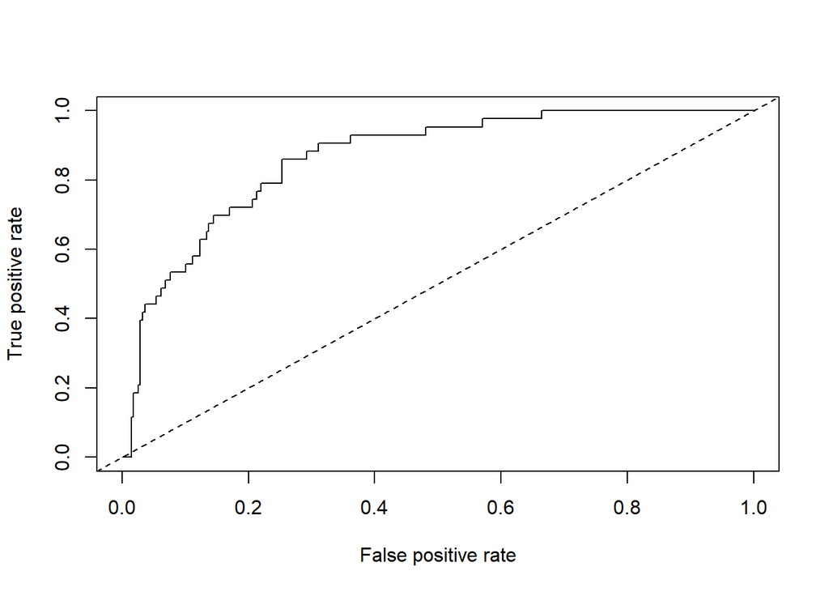

```r
#create prediction object
wine_roc_tun <- prediction(predictions = wine_predProb_tun[, 2],
                       labels = as.numeric(wine.test$class == "Good"))

#create performance with prediction object
perf_tun <- performance(prediction.obj = wine_roc_tun,
                    measure = "tpr", # tpr = true positive rate
                    x.measure = "fpr") #fpr = false positive rate

#create lot
plot(perf_tun)
abline(0,1, lty = 2)
```

Based on plot, line make a curve arc (High True Positive and Low False Positive) its mean good model

2. Area Under ROC Curve (AUC)

AUC show large are under ROC curve, parameter AUC if value close to 1, model good.

```r
auc_tun <- performance(prediction.obj = wine_roc_tun,
                   measure = "auc")
auc_tun@y.values
```

```
## [[1]]
## [1] 0.864411
```

Value AUC 0.864411, close to 1 its means good model

#### #Without using Tunning

**Make Naive Bayes Model**

```r
model_naive <- naiveBayes(x = wine.train %>% select(-class),
                          y = wine.train$class,
                          laplace = 1)
```

**Make Prediction and Evaluation Model**

```r
pred_naive <- predict(object= model_naive,
                           newdata = wine.test,
                           type="class")

confusionMatrix(data= pred_naive,
                reference= wine.test$class,
                positive="Good")
```

```
## Confusion Matrix and Statistics
##
##           Reference
## Prediction Bad Good
##       Bad  246   18
##       Good  31   25
##
##                Accuracy : 0.8469
##                  95% CI : (0.8027, 0.8845)
##     No Information Rate : 0.8656
##     P-Value [Acc > NIR] : 0.85622
##
##                   Kappa : 0.4163
##
##  Mcnemar's Test P-Value : 0.08648
##
##             Sensitivity : 0.58140
##             Specificity : 0.88809
##          Pos Pred Value : 0.44643
##          Neg Pred Value : 0.93182
##              Prevalence : 0.13437
##          Detection Rate : 0.07812
##    Detection Prevalence : 0.17500
##       Balanced Accuracy : 0.73474
##
##        'Positive' Class : Good
##
```

**Check Performance Model**

1. Receiver-Operating Curve (ROC)

ROC is a curve are plots correlation between True Positive Rate (Sensitivity or Recall) and False Positive Rate (Specificity). Good model ideally “High TP and Low FP”

```r
wine_predProb <- predict(model_naive, newdata = wine.test,type = "raw")
head(wine_predProb)
```

```
##            Bad        Good
## [1,] 0.9949913 0.005008735
## [2,] 0.8762924 0.123707645
## [3,] 0.7924593 0.207540685
## [4,] 0.9942464 0.005753589
## [5,] 0.9877532 0.012246844
## [6,] 0.9649074 0.035092576
```

Check ROC with plot

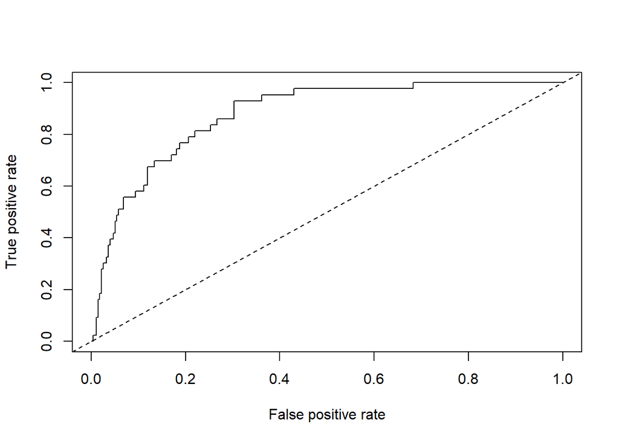

```r
#create prediction object
wine_roc <- prediction(predictions = wine_predProb[, 2],
                       labels = as.numeric(wine.test$class == "Good"))

#create performance with prediction object
perf <- performance(prediction.obj = wine_roc,
                    measure = "tpr", # tpr = true positive rate
                    x.measure = "fpr") #fpr = false positive rate

#create lot
plot(perf)
abline(0,1, lty = 2)
```

Based on plot, line make a curve arc (High True Positive and Low False Positive) its mean good model

2. Area Under ROC Curve (AUC)

AUC show large are under ROC curve, parameter AUC if value close to 1, model good.

```r
auc<- performance(prediction.obj = wine_roc,
                   measure = "auc")
auc@y.values
```

```
## [[1]]
## [1] 0.8764168
```

Value AUC 0.8764168, close to 1 its means good model

**Interpretation Naive Bayes Model**

Based on Confussion Matrix model Naive Bayes, value Accuracy (0.7312 or 73.1%) and (Recall 0.8837 or 88.3% model). Its means Accuracy model can predict quality wine Good or Bad 73.1% and model can predict quality wine Good is 88.3%.

### Decision Tree

#### #Without using Tunning

**Make Decision Tree Model**

```r
set.seed(1616)
model_dt <- ctree(class ~ ., wine)
```

**Make Prediction and Evaluation Model**

Prediction and Evaluation Model using *data test*

```r
pred_dt <- predict(model_dt, newdata = wine.test, type = "response")

confusionMatrix(pred_dt, wine.test$class, positive = "Good")
```

```
## Confusion Matrix and Statistics
##
##           Reference
## Prediction Bad Good
##       Bad  267   23
##       Good  10   20
##
##                Accuracy : 0.8969
##                  95% CI : (0.8582, 0.9279)
##     No Information Rate : 0.8656
##     P-Value [Acc > NIR] : 0.05594
##
##                   Kappa : 0.4918
##
##  Mcnemar's Test P-Value : 0.03671
##
##             Sensitivity : 0.46512
##             Specificity : 0.96390
##          Pos Pred Value : 0.66667
##          Neg Pred Value : 0.92069
##              Prevalence : 0.13437
##          Detection Rate : 0.06250
##    Detection Prevalence : 0.09375
##       Balanced Accuracy : 0.71451
##
##        'Positive' Class : Good
##
```

Prediction and Evaluation Model using *data train*

```r
pred_dt_train <- predict(model_dt, newdata = wine.train, type = "response")
confusionMatrix(pred_dt_train, wine.train$class, positive = "Good")
```

```
## Confusion Matrix and Statistics
##
##           Reference
## Prediction  Bad Good
##       Bad  1058   87
##       Good   47   87
##
##                Accuracy : 0.8952
##                  95% CI : (0.8771, 0.9115)
##     No Information Rate : 0.864
##     P-Value [Acc > NIR] : 0.0004409
##
##                   Kappa : 0.5065
##
##  Mcnemar's Test P-Value : 0.0007542
##
##             Sensitivity : 0.50000
##             Specificity : 0.95747
##          Pos Pred Value : 0.64925
##          Neg Pred Value : 0.92402
##              Prevalence : 0.13604
##          Detection Rate : 0.06802
##    Detection Prevalence : 0.10477
##       Balanced Accuracy : 0.72873
##
##        'Positive' Class : Good
##
```

**Summary Prediction and Evaluation**

```r
model_dt_recap <- c("wine.test", "wine.train")
Accuracy <- c(0.8969,0.8952)
Recall <- c(0.4651,0.5000)

tabelmodelrecap <- data.frame(model_dt_recap,Accuracy,Recall)

print(tabelmodelrecap)
```

```
##   model_dt_recap Accuracy Recall
## 1      wine.test   0.8969 0.4651
## 2     wine.train   0.8952 0.5000
```

#### #Using Tunning

**Tuning Model**

Create new model with pruning treatment

```r
set.seed(1616)

model_dt_tuned <- ctree(class ~ ., wine_train_down,
                        control = ctree_control(mincriterion = 0.5,
                                                minsplit = 35, #40
                                                minbucket = 20)) #12
```

**Make Prediction and Evaluation Model**

Prediction and Evaluation Model using *data test*

```r
pred_dt_test_tunes <- predict(model_dt_tuned, newdata = wine.test, type = "response")
confusionMatrix(pred_dt_test_tunes, wine.test$class, positive = "Good")
```

```
## Confusion Matrix and Statistics
##
##           Reference
## Prediction Bad Good
##       Bad  219   10
##       Good  58   33
##
##                Accuracy : 0.7875
##                  95% CI : (0.7385, 0.831)
##     No Information Rate : 0.8656
##     P-Value [Acc > NIR] : 1
##
##                   Kappa : 0.3792
##
##  Mcnemar's Test P-Value : 0.00000001201
##
##             Sensitivity : 0.7674
##             Specificity : 0.7906
##          Pos Pred Value : 0.3626
##          Neg Pred Value : 0.9563
##              Prevalence : 0.1344
##          Detection Rate : 0.1031
##    Detection Prevalence : 0.2844
##       Balanced Accuracy : 0.7790
##
##        'Positive' Class : Good
##
```

Prediction and Evaluation Model using *data train*

```r
pred_dt_train_tunes <- predict(model_dt_tuned, newdata = wine_train_down, type = "response")
confusionMatrix(pred_dt_train_tunes, wine_train_down$class, positive = "Good")
```

```
## Confusion Matrix and Statistics
##
##           Reference
## Prediction Bad Good
##       Bad  142   36
##       Good  32  138
##
##                Accuracy : 0.8046
##                  95% CI : (0.759, 0.8449)
##     No Information Rate : 0.5
##     P-Value [Acc > NIR] : <0.0000000000000002
##
##                   Kappa : 0.6092
##
##  Mcnemar's Test P-Value : 0.716
##
##             Sensitivity : 0.7931
##             Specificity : 0.8161
##          Pos Pred Value : 0.8118
##          Neg Pred Value : 0.7978
##              Prevalence : 0.5000
##          Detection Rate : 0.3966
##    Detection Prevalence : 0.4885
##       Balanced Accuracy : 0.8046
##
##        'Positive' Class : Good
##
```

**Summary Prediction and Evaluation**

```r
model_dt_recap_tuning <- c("wine.test.tuning", "wine.train.tuning")
Accuracy_tuning <- c(0.7875,0.8046)
Recall_tuning <- c(0.7674,0.7931)

tabelmodelrecap2 <- data.frame(model_dt_recap_tuning,Accuracy_tuning,Recall_tuning)

print(tabelmodelrecap2)
```

```
##   model_dt_recap_tuning Accuracy_tuning Recall_tuning
## 1      wine.test.tuning          0.7875        0.7674
## 2     wine.train.tuning          0.8046        0.7931
```

#### Compare with using tuning and without tuning

```r
model_dt_recap_all <- c("wine.test", "wine.train", "wine.test.tuning", "wine.train.tuning")
Accuracy <- c(0.8969,0.8952,0.7875,0.8046)
Recall <- c(0.4651,0.5000,0.7674,0.7931)

tabelmodelrecapall <- data.frame(model_dt_recap_all,Accuracy,Recall)

print(tabelmodelrecapall)
```

```
##   model_dt_recap_all Accuracy Recall
## 1          wine.test   0.8969 0.4651
## 2         wine.train   0.8952 0.5000
## 3   wine.test.tuning   0.7875 0.7674
## 4  wine.train.tuning   0.8046 0.7931
```

**Create Plot Decision Tree**

```r
model_dt_tuned
```

```
##
## Model formula:
## class ~ fixed.acidity + volatile.acidity + citric.acid + residual.sugar +
##     chlorides + free.sulfur.dioxide + total.sulfur.dioxide +
##     density + pH + sulphates + alcohol
##
## Fitted party:
## [1] root
## |   [2] alcohol <= 10.4
## |   |   [3] fixed.acidity <= 10.1
## |   |   |   [4] alcohol <= 9.9
## |   |   |   |   [5] volatile.acidity <= 0.52: Bad (n = 27, err = 11.1%)
## |   |   |   |   [6] volatile.acidity > 0.52: Bad (n = 48, err = 0.0%)
## |   |   |   [7] alcohol > 9.9: Bad (n = 31, err = 29.0%)
## |   |   [8] fixed.acidity > 10.1: Bad (n = 21, err = 47.6%)
## |   [9] alcohol > 10.4
## |   |   [10] volatile.acidity <= 0.66
## |   |   |   [11] sulphates <= 0.61
## |   |   |   |   [12] pH <= 3.27: Good (n = 20, err = 25.0%)
## |   |   |   |   [13] pH > 3.27: Bad (n = 23, err = 34.8%)
## |   |   |   [14] sulphates > 0.61: Good (n = 150, err = 18.0%)
## |   |   [15] volatile.acidity > 0.66: Bad (n = 28, err = 21.4%)
##
## Number of inner nodes:    7
## Number of terminal nodes: 8
```

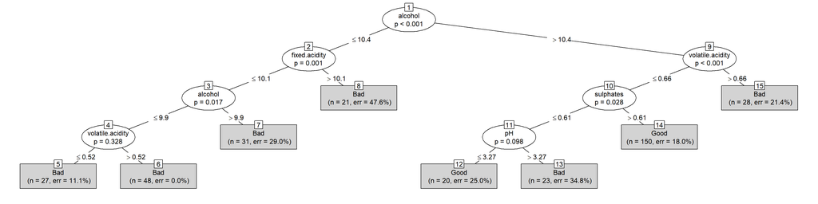

```r
plot(model_dt_tuned,type="simple")
```

**Interpretation Decision Tree Model**

- Nodes 1 is Root Nodes (Highest node in the tree structure, and has no parent)
- Nodes 2,3,4,9,10,and 11 is Inner Nodes (Node of a tree that has child nodes)
- Nodes 5,6,7,8,12,13,14,and 15 is Terminal Nodes (Node that does not have child nodes)

### Random Forest

#### #Using Tuning

**K-Fold Cross Validation**

Split data by $k$ part, where each part is used to testing data.

Make model random forest using 5-fold cross validation and repeat process 3 times, after that save on RDS

```r
set.seed(1616)

ctrl <- trainControl(method = "repeatedcv",
                      number = 5,
                      repeats = 3)

model_forest_tun <- train(class ~ .,
                  data = wine_train_down,
                  method = "rf",
                  trControl = ctrl)
saveRDS(model_forest_tun, "model_forest_update_tun.RDS")
```

**Make Random Forest Model**

Read RDS with name model_rf

```r
model_rf_tun <- readRDS("model_forest_update_tun.RDS")
model_rf_tun
```

```
## Random Forest
##
## 348 samples
##  11 predictor
##   2 classes: 'Bad', 'Good'
##
## No pre-processing
## Resampling: Cross-Validated (5 fold, repeated 3 times)
## Summary of sample sizes: 278, 279, 279, 278, 278, 278, ...
## Resampling results across tuning parameters:
##
##   mtry  Accuracy   Kappa
##    2    0.8151228  0.6304040
##    6    0.8075046  0.6152018
##   11    0.8035696  0.6073220
##
## Accuracy was used to select the optimal model using the largest value.
## The final value used for the model was mtry = 2.
```

Use model with mtry (predictor) = 2, because value accuracy more than other mtry

**Model Evaluation**

Check model error (OOB or Out-Off-Bag) with finalModel

```r
model_rf_tun$finalModel
```

```
##
## Call:
##  randomForest(x = x, y = y, mtry = param$mtry)
##                Type of random forest: classification
##                      Number of trees: 500
## No. of variables tried at each split: 2
##
##         OOB estimate of  error rate: 16.95%
## Confusion matrix:
##      Bad Good class.error
## Bad  132   42  0.24137931
## Good  17  157  0.09770115
```

Result (OOB or Out-Off-Bag) is 16.95% , its mean this model has 83.05% of accuracy

**Check Importance Variabel**

```r
varImp(model_rf_tun)
```

```
## rf variable importance
##
##                      Overall
## alcohol              100.000
## sulphates             80.404
## volatile.acidity      65.344
## citric.acid           44.923
## total.sulfur.dioxide  27.964
## density               20.919
## chlorides             20.045
## fixed.acidity         19.735
## residual.sugar         4.417
## pH                     4.370
## free.sulfur.dioxide    0.000
```

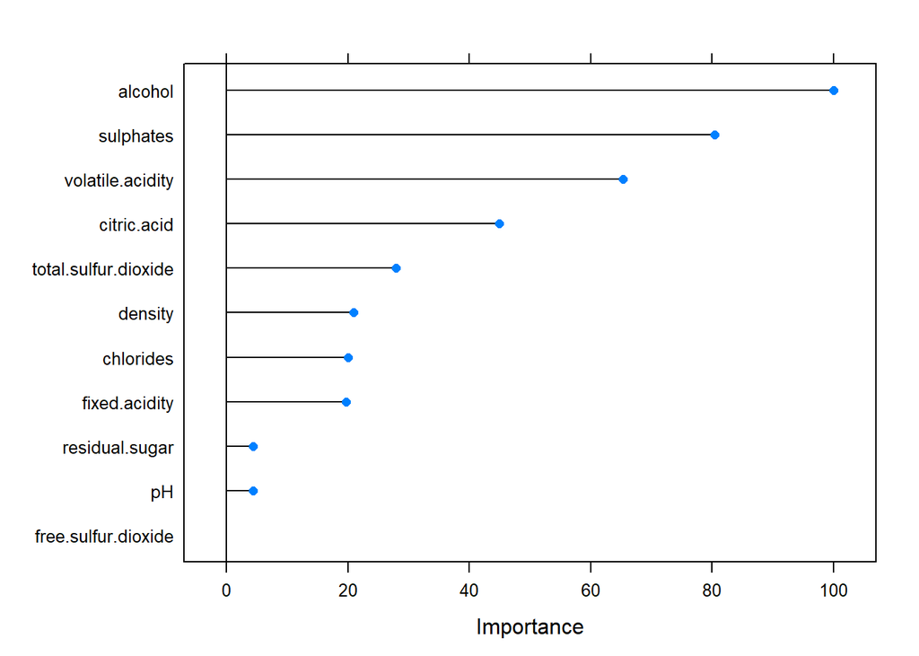

```r
plot(varImp(model_rf_tun))
```

Based on plot above, 3 most important variable is alcohol, sulphates and volatile.acidity

**Make Prediction and Evaluation Model**

Make prediction and check model evaluation with positive class “Good” using data_test

```r
pred_rf_tun <- predict(model_rf_tun, wine.test, type = "raw")
confusionMatrix(pred_rf_tun, wine.test$class, positive = "Good")
```

```
## Confusion Matrix and Statistics
##
##           Reference
## Prediction Bad Good
##       Bad  210    4
##       Good  67   39
##
##                Accuracy : 0.7781
##                  95% CI : (0.7286, 0.8225)
##     No Information Rate : 0.8656
##     P-Value [Acc > NIR] : 1
##
##                   Kappa : 0.4108
##
##  Mcnemar's Test P-Value : 0.0000000000001866
##
##             Sensitivity : 0.9070
##             Specificity : 0.7581
##          Pos Pred Value : 0.3679
##          Neg Pred Value : 0.9813
##              Prevalence : 0.1344
##          Detection Rate : 0.1219
##    Detection Prevalence : 0.3312
##       Balanced Accuracy : 0.8325
##
##        'Positive' Class : Good
##
```